# Gilbert_act_report

## Report: act_report

- Create a **250-word-minimum written report** called "act_report.pdf" or "act_report.html" that communicates the insights and displays the visualization(s) produced from your wrangled data. This is to be framed as an external document, like a blog post or magazine article, for example.

### INSIGHTS AND VISUALISATION OF [WeRateDogs](https://twitter.com/dog_rates?s=20&t=WVC6h7yzsvn6F21iUlaDOw) TWITTER ARCHIVE.

[figure not shown]

In order to the get insights from WeRateDogs' archive data, WeRateDogs downloaded their Twitter archive and sent it to Udacity via email. This archive contains basic tweet data(tweet ID, timestamp, text, etc.) for all 5000+ of their tweets as they stood on August 1, 2017. I also had to access Twitter's API to get more details about each tweet in the archive using their tweet ID and then I downloaded an image prediction dataset that contained predictions of the kind of dog breed in all the images attached to the tweets in the archive. The image prediction dataset was generated by a neural network image prediction algorithm that can classify breeds of dogs. The average percentage confidence of the image prediction algorithm is approximately **62%**

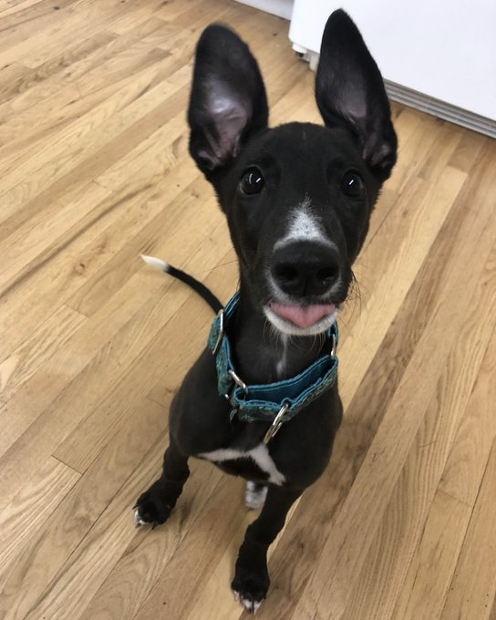

After going through the data wrangling - gathering, assessing, cleaning - process and then storing the cleaned dataset in a master dataframe, I queried the dataset a bit. From these queries, I found some interesting insight which includes:

- The average hour when tweet get posted on [WeRateDogs](https://twitter.com/dog_rates?s=20&t=WVC6h7yzsvn6F21iUlaDOw) is approximately 10am UTC
- The average number of [WeRateDogs](https://twitter.com/dog_rates?s=20&t=WVC6h7yzsvn6F21iUlaDOw) tweet status engagement via likes (favorite_count) is approximately **8417** and the maximum is **144907**.
- The average number of [WeRateDogs](https://twitter.com/dog_rates?s=20&t=WVC6h7yzsvn6F21iUlaDOw) tweet status engagement via retweets (retweet_count) is approximately **2410** and the maximum is **70752**

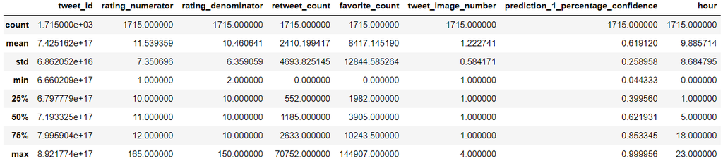

- The most common dog breed by count of image predicted by image prediction algorithm is the **Golden retriever**

One research question was posed in other to gain some more insight on the data and with the aid of visualization, I was able to repesent the answer to this question.

### Research Question: What are the top 5 most rated dog breed by count of image posted with WeRateDog tweet rating?

As was mentioned earlier, most of the dog image attached to each rating tweet by [WeRateDogs](https://twitter.com/dog_rates?s=20&t=WVC6h7yzsvn6F21iUlaDOw) was passed through a neural network than can classify dog breed by predicting the breed of a dog in an image with an average prediction confidence of 62% and it was found that the five most rated dog breed by count of all tweet rating posted with a dog image were:

- golden retriever breed
- Labrador retriever breed
- pembroke breed
- chihuahua breed
- pug breed

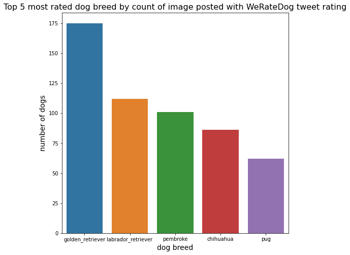